# Analises gitHub Archive

Rodolfo Viana

26-05-2016

```r
library(dplyr)
library(tm)
library(wordcloud)
library(ggplot2)
```

## Commits e Descrições dos projetos mais ativos

Com o finalidade de identificar qual são o conjunto de palavas mais utilizadas pelos projetos mais ativos de 2014 criamos a análise a seguir.

Inicialmente iremos construir uma nuvem de palavras para descobrir quais são as palavras mais utilizadas e se existe alguma inconsistência nos dados

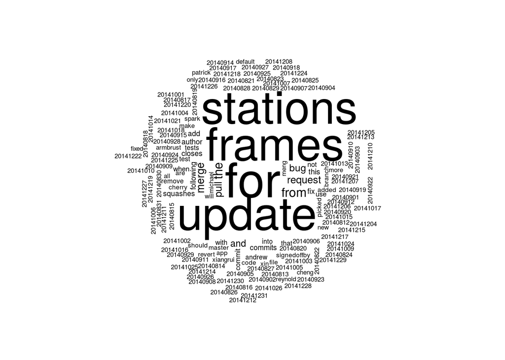

```r
descricao.commit <- read.csv("dados/descricao-commit.csv")

review_text <- paste(unique(as.character(descricao.commit$payload_commit_msg)), collapse=" ")
review_source <- VectorSource(review_text)
corpus <- Corpus(review_source)

corpus <- tm_map(corpus, content_transformer(tolower))
corpus <- tm_map(corpus, removePunctuation)
corpus <- tm_map(corpus, stripWhitespace)

dtm <- DocumentTermMatrix(corpus)
dtm2 <- as.matrix(dtm)
frequency <- colSums(dtm2)
frequency <- sort(frequency, decreasing = TRUE)

words <- names(frequency)
set.seed(1363)
wordcloud(words[1:200], frequency[1:200], min.freq = 5, max.words = 150, random.order = FALSE, rot.per=0.20)
```

Podemos notar que as palavras **FOR, UPDATE, FRAMES e STATIONS** são as palavras mais utilizadas. É possível notar que aparece números com frequência, em uma investigação rápida, esses números representam datas. Eu pensei que a palavra **BUG** iria aparecer com mais frequência.

Analisando agora as descrições dos repositórios temos:

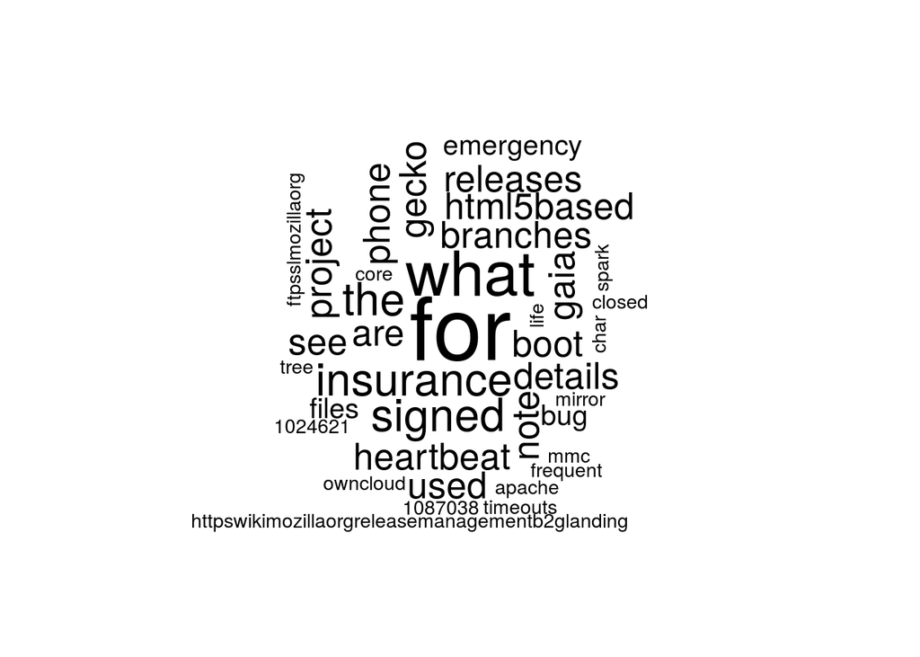

```r
review_text <- paste(unique(as.character(descricao.commit$repository_description)), collapse=" ")
review_source <- VectorSource(review_text)
corpus <- Corpus(review_source)

corpus <- tm_map(corpus, content_transformer(tolower))
corpus <- tm_map(corpus, removePunctuation)
corpus <- tm_map(corpus, stripWhitespace)

dtm <- DocumentTermMatrix(corpus)
dtm2 <- as.matrix(dtm)
frequency <- colSums(dtm2)
frequency <- sort(frequency, decreasing = TRUE)

words <- names(frequency)
set.seed(1363)
wordcloud(words[1:38], frequency[1:38], min.freq = 0, max.words = 150, random.order = FALSE, rot.per=0.20)
```

A palavra **FOR** apareceu novamente como sendo uma das mais utilizadas nas descrições das palavras. Por se tratar de uma stopword decidimos por realizar novamente o processamento e dessa vez excluir as stopwords. No inglês temos as seguintes stopwords

```r
stopwords("english")
```

```
##   [1] "i"          "me"         "my"         "myself"     "we"
##   [6] "our"        "ours"       "ourselves"  "you"        "your"
##  [11] "yours"      "yourself"   "yourselves" "he"         "him"
##  [16] "his"        "himself"    "she"        "her"        "hers"
##  [21] "herself"    "it"         "its"        "itself"     "they"
##  [26] "them"       "their"      "theirs"     "themselves" "what"
##  [31] "which"      "who"        "whom"       "this"       "that"
##  [36] "these"      "those"      "am"         "is"         "are"
##  [41] "was"        "were"       "be"         "been"       "being"
##  [46] "have"       "has"        "had"        "having"     "do"
##  [51] "does"       "did"        "doing"      "would"      "should"
##  [56] "could"      "ought"      "i'm"        "you're"     "he's"
##  [61] "she's"      "it's"       "we're"      "they're"    "i've"
##  [66] "you've"     "we've"      "they've"    "i'd"        "you'd"
##  [71] "he'd"       "she'd"      "we'd"       "they'd"     "i'll"
```

[output cut: 20 more lines]

A nova nuvem de palavras agora sem as stopwords temos:

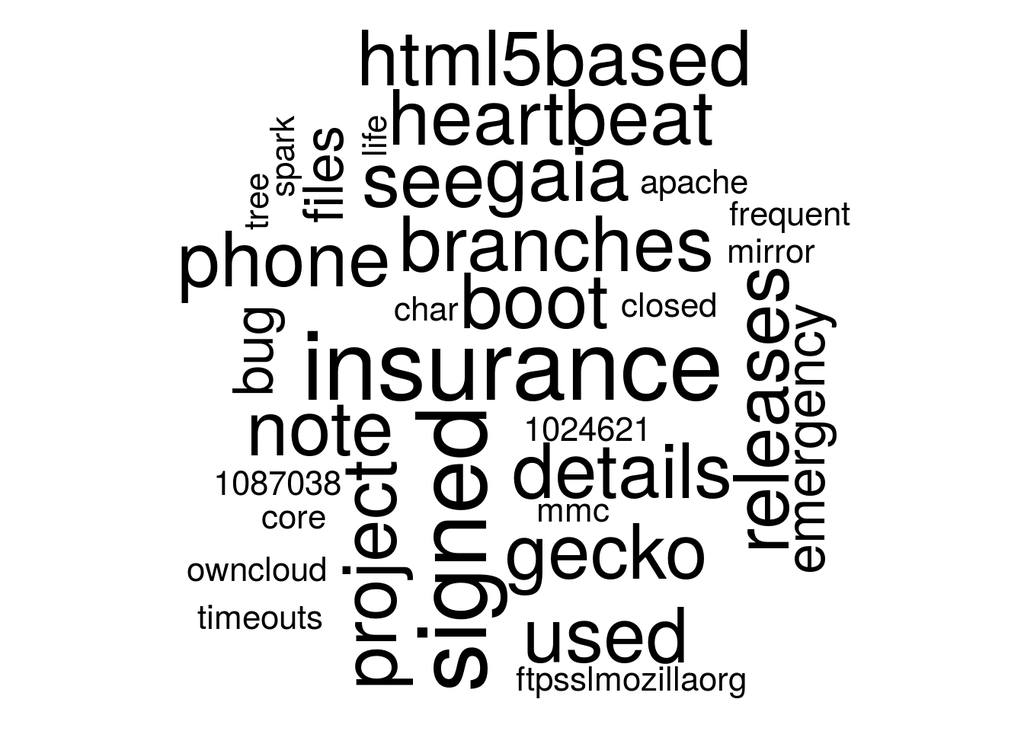

```r
review_text <- paste(unique(as.character(descricao.commit$repository_description)), collapse=" ")
review_source <- VectorSource(review_text)
corpus <- Corpus(review_source)

corpus <- tm_map(corpus, content_transformer(tolower))
corpus <- tm_map(corpus, removePunctuation)
corpus <- tm_map(corpus, stripWhitespace)
corpus <- tm_map(corpus, removeWords, stopwords("english"))

dtm <- DocumentTermMatrix(corpus)
dtm2 <- as.matrix(dtm)
frequency <- colSums(dtm2)
frequency <- sort(frequency, decreasing = TRUE)

words <- names(frequency)
set.seed(1363)
wordcloud(words[1:34], frequency[1:34], min.freq = 0, max.words = 150, random.order = FALSE, rot.per=0.20)
```

Excluindo as stopWords ficamos com a palavra **Insurance** como sendo a mais usada nas descrições dos 100 projetos mais ativos do github no ano de 2014

## User mais ativos

Na lista dos 1000 users que mais contribuíram em projetos do github, apenas 70 aparecem na lista dos 1000 mais ativos entre os anos de 2011 e 2014.

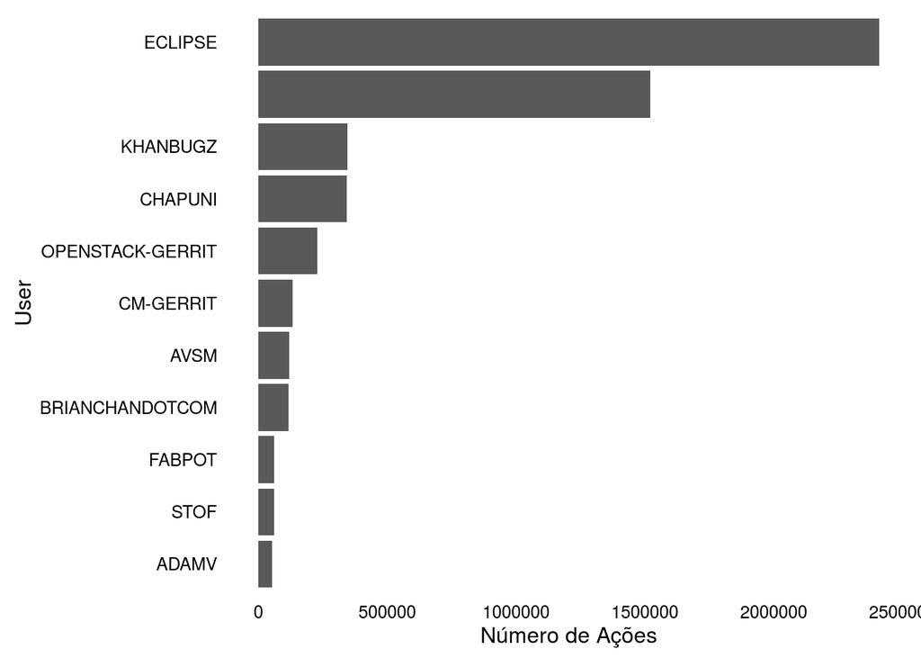

```r
user.2011 <- read.csv("dados/pessoas_mais_ativas_2011.csv")
user.2012 <- read.csv("dados/pessoas_mais_ativas_2012.csv")
user.2013 <- read.csv("dados/pessoas_mais_ativas_2013.csv")
user.2014 <- read.csv("dados/pessoas_mais_ativas_2014.csv")

user2011.2012 <- full_join(user.2011, user.2012, by = "actor")
user2013.2014 <- full_join(user.2013, user.2014, by = "actor")
user2011.2014 <- full_join(user2011.2012, user2013.2014, by = "actor")

user2011.2014 <- user2011.2014[complete.cases(user2011.2014),]
colnames(user2011.2014) <- c("user", "2011", "2012", "2013", "2014")

user2011.2014$total <- user2011.2014$"2011" + user2011.2014$"2012" + user2011.2014$"2013" + user2011.2014$"2014"

user.top10 <- head(user2011.2014[with(user2011.2014, order(-total, total)), ], 11)

ggplot(user.top10, aes(x = reorder(toupper(user), total), y = total)) +
  geom_bar(stat="identity") +
  labs(y='Número de Ações', x='User') +
  theme_classic() +
  theme(axis.ticks = element_blank()) +
  coord_flip()
```

É possível notar que o segundo lugar é um nome em branco, por acreditar que se trata de algum erro dos dados do github decidimos por excluir.

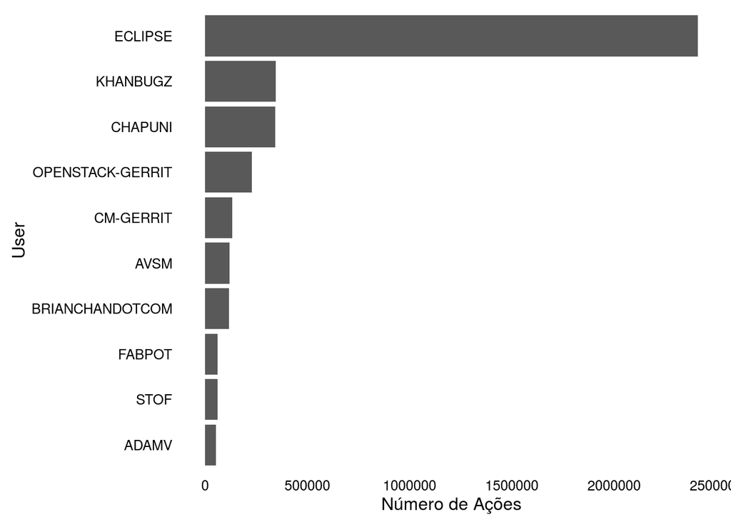

```r
user.top10 <- filter(user.top10, user != "")

ggplot(user.top10, aes(x = reorder(toupper(user), total), y = total)) +
  geom_bar(stat="identity") +
  labs(y='Número de Ações', x='User') +
  theme_classic() +
  theme(axis.ticks = element_blank()) +
  coord_flip()
```

É possível notar alguns users importantes, como por exemplo o Eclipse e o OpenStack.

Analisando apenas o user Eclipse, podemos notar que:

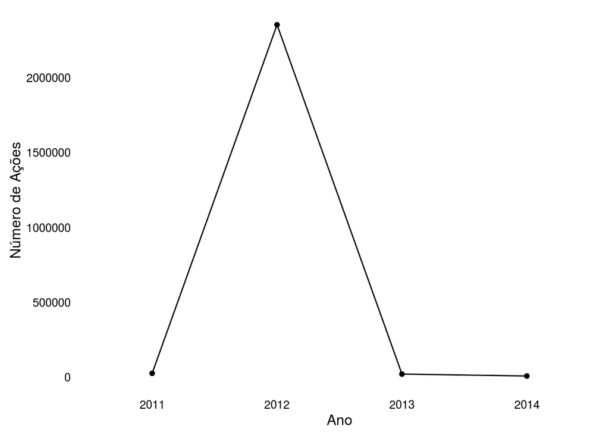

```r
toPlot <- head(user.top10,1)
toPlot <- data.frame(Ano = c("2011", "2012", "2013", "2014"),
           Contribuicao = c(toPlot$"2011", toPlot$"2012", toPlot$"2013", toPlot$"2014"))

toPlot$user <- "eclipse"

ggplot(toPlot, aes(x = Ano, y = Contribuicao, group = user)) +
  geom_line() +
    geom_point() +
  labs(y='Número de Ações', x='Ano') +
  theme_classic() +
  theme(axis.ticks = element_blank())
```

No ano de 2012 teve um grande volume de contribuição. A título de comparação, 2012 teve 90 vezes mais contribuição do que em 2011.